# Análise Discriminante

Ricardo Limongi

2025-03-20

# 1. Introdução à Análise Discriminante Linear (LDA)

A Análise Discriminante Linear (LDA) é uma técnica estatística desenvolvida por Ronald Fisher em 1936 que busca encontrar combinações lineares de características (variáveis) que melhor separam duas ou mais classes de objetos ou eventos. Na área da saúde, a LDA pode ser extremamente útil para:

- Diagnóstico de doenças com base em múltiplos biomarcadores
- Classificação de pacientes em grupos de risco
- Identificação de fatores mais relevantes na discriminação entre grupos de pacientes
- Desenvolvimento de regras de decisão para triagem clínica

## 1.1 Principais características da LDA:

- É uma técnica supervisionada (necessita de dados previamente rotulados)
- Pressupõe normalidade multivariada das variáveis independentes
- Assume homogeneidade de variâncias-covariâncias entre grupos
- Busca maximizar a separação entre grupos enquanto minimiza a variação dentro dos grupos
- Pode ser usada tanto para classificação quanto para redução de dimensionalidade

# 2. Análise de Risco Cardiovascular - Um Caso Prático

Neste exemplo, vamos utilizar a LDA para classificar pacientes em grupos de risco cardiovascular com base em diversos indicadores de saúde.

## 2.1 Carregando as bibliotecas necessárias

```r
# Carregar pacotes necessários
library(MASS)      # Para função lda()
library(dplyr)     # Para manipulação de dados
library(ggplot2)   # Para visualização
library(caret)     # Para validação e métricas
library(klaR)      # Para visualização da LDA
```

## 2.2 Preparando o conjunto de dados

Para este exemplo, usaremos dados simulados que representam indicadores de saúde cardiovascular de pacientes.

```r
# Definir seed para reprodutibilidade
set.seed(123)

# Criar amostra de pacientes de baixo risco cardiovascular
baixo_risco <- data.frame(
  idade = rnorm(100, mean = 45, sd = 8),
  pressao_sistolica = rnorm(100, mean = 120, sd = 10),
  colesterol_total = rnorm(100, mean = 190, sd = 20),
  hdl = rnorm(100, mean = 55, sd = 8),
  triglicerideos = rnorm(100, mean = 120, sd = 30),
  glicemia = rnorm(100, mean = 85, sd = 10),
  imc = rnorm(100, mean = 24, sd = 2.5),
  grupo = factor("Baixo Risco")
)

# Criar amostra de pacientes de médio risco cardiovascular
medio_risco <- data.frame(
  idade = rnorm(100, mean = 55, sd = 7),
  pressao_sistolica = rnorm(100, mean = 135, sd = 12),
  colesterol_total = rnorm(100, mean = 215, sd = 25),
  hdl = rnorm(100, mean = 45, sd = 7),
  triglicerideos = rnorm(100, mean = 160, sd = 40),
  glicemia = rnorm(100, mean = 100, sd = 15),
  imc = rnorm(100, mean = 27, sd = 3),
  grupo = factor("Médio Risco")
)

# Criar amostra de pacientes de alto risco cardiovascular
alto_risco <- data.frame(
  idade = rnorm(100, mean = 65, sd = 9),
  pressao_sistolica = rnorm(100, mean = 150, sd = 15),
  colesterol_total = rnorm(100, mean = 240, sd = 30),
  hdl = rnorm(100, mean = 35, sd = 6),
  triglicerideos = rnorm(100, mean = 210, sd = 50),
  glicemia = rnorm(100, mean = 120, sd = 25),
  imc = rnorm(100, mean = 31, sd = 3.5),
  grupo = factor("Alto Risco")
)

# Combinar os três grupos
dados <- rbind(baixo_risco, medio_risco, alto_risco)

# Visualizar a estrutura dos dados
str(dados)
```

```
## 'data.frame':    300 obs. of  8 variables:
##  $ idade            : num  40.5 43.2 57.5 45.6 46 ...
##  $ pressao_sistolica: num  113 123 118 117 110 ...
##  $ colesterol_total : num  234 216 185 201 182 ...
##  $ hdl              : num  49.3 49 47.5 46.6 51.5 ...
##  $ triglicerideos   : num  117.8 84.9 101 119.1 140.1 ...
##  $ glicemia         : num  79 75.1 95.3 92.5 69.9 ...
##  $ imc              : num  26.7 23.9 23.9 20.2 26 ...
##  $ grupo            : Factor w/ 3 levels "Baixo Risco",..: 1 1 1 1 1 1 1 1 1 1 ...
```

```r
# Resumo estatístico dos dados
summary(dados)
```

```
##      idade       pressao_sistolica colesterol_total      hdl
##  Min.   :26.53   Min.   : 99.47    Min.   :154.9    Min.   :16.71
##  1st Qu.:47.06   1st Qu.:120.96    1st Qu.:190.3    1st Qu.:36.73
##  Median :55.53   Median :134.16    Median :214.4    Median :44.89
##  Mean   :55.77   Mean   :135.19    Mean   :216.5    Mean   :45.25
##  3rd Qu.:63.66   3rd Qu.:148.38    3rd Qu.:234.8    3rd Qu.:52.42
##  Max.   :85.56   Max.   :181.91    Max.   :338.7    Max.   :75.57
##  triglicerideos      glicemia           imc                grupo
##  Min.   : 40.17   Min.   : 54.90   Min.   :17.50   Baixo Risco:100
##  1st Qu.:125.96   1st Qu.: 85.07   1st Qu.:23.88   Médio Risco:100
##  Median :155.70   Median : 97.88   Median :26.77   Alto Risco :100
##  Mean   :165.22   Mean   :102.12   Mean   :27.01
##  3rd Qu.:202.15   3rd Qu.:113.79   3rd Qu.:29.82
##  Max.   :330.68   Max.   :190.40   Max.   :38.20
```

## 2.3 Análise exploratória dos dados

Antes de aplicar a LDA, é importante explorar os dados para entender as características de cada grupo e verificar se existem padrões visíveis.

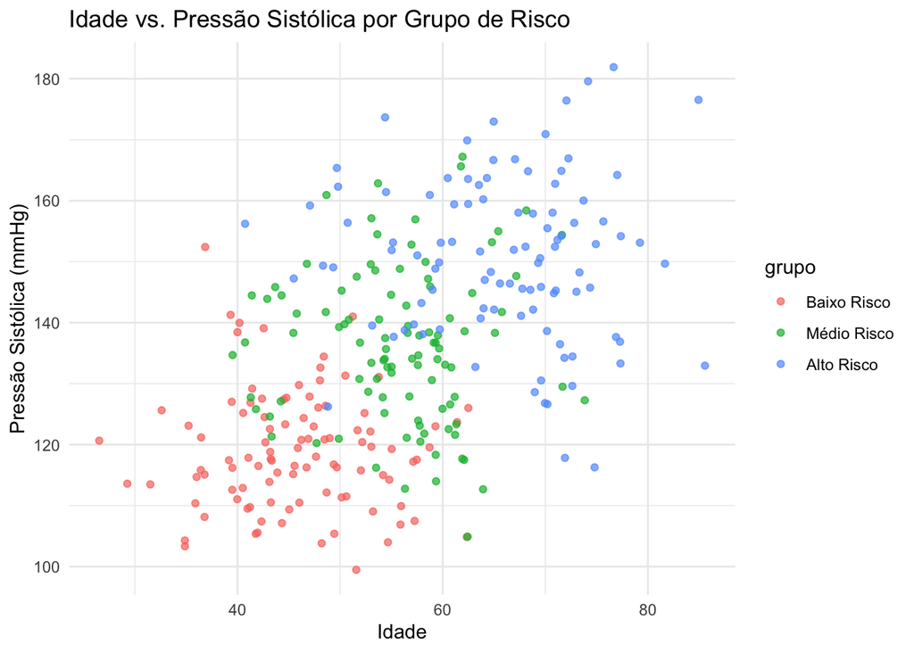

```r
# Visualizar a distribuição das variáveis por grupo
ggplot(dados, aes(x = idade, y = pressao_sistolica, color = grupo)) +
  geom_point(alpha = 0.7) +
  labs(title = "Idade vs. Pressão Sistólica por Grupo de Risco",
       x = "Idade", y = "Pressão Sistólica (mmHg)") +
  theme_minimal()
```

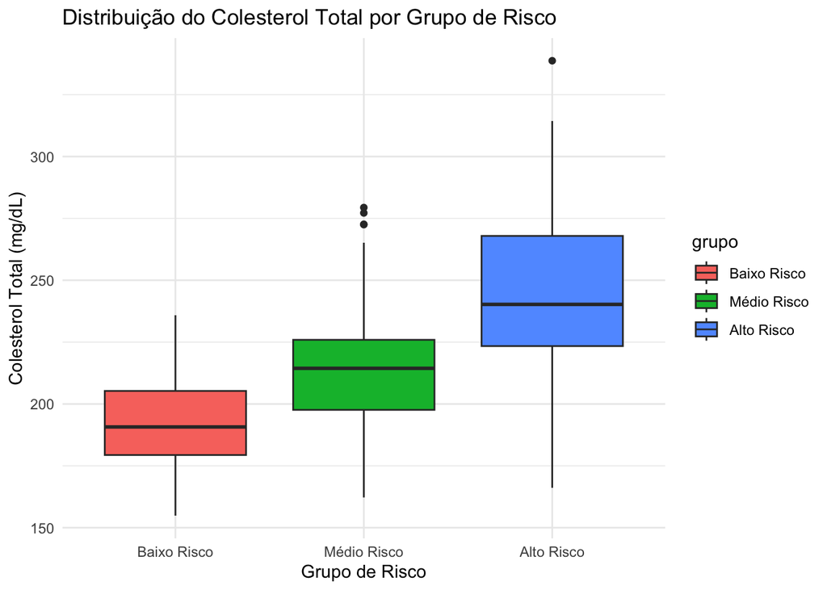

```r
# Boxplots para comparar as distribuições por grupo
ggplot(dados, aes(x = grupo, y = colesterol_total, fill = grupo)) +
  geom_boxplot() +
  labs(title = "Distribuição do Colesterol Total por Grupo de Risco",
       x = "Grupo de Risco", y = "Colesterol Total (mg/dL)") +
  theme_minimal()
```

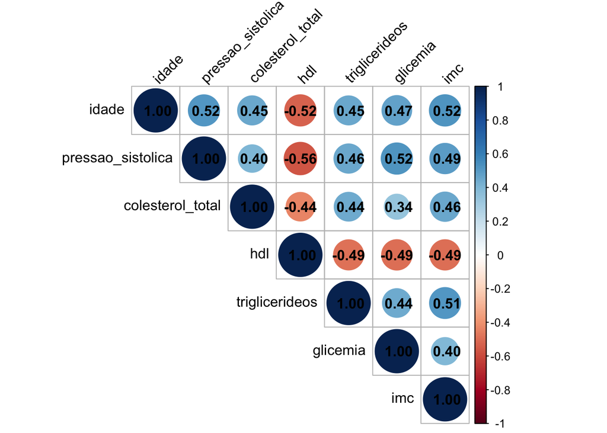

```r
# Matriz de correlação entre as variáveis
cor_matrix <- cor(dados[, 1:7])
corrplot::corrplot(cor_matrix, method = "circle", type = "upper",
                  tl.col = "black", tl.srt = 45, addCoef.col = "black")
```

# 3. Aplicação da Análise Discriminante Linear

## 3.1 Divisão dos dados em treino e teste

```r
# Dividir os dados em conjunto de treino (70%) e teste (30%)
set.seed(456)
indices_treino <- createDataPartition(dados$grupo, p = 0.7, list = FALSE)
dados_treino <- dados[indices_treino, ]
dados_teste <- dados[-indices_treino, ]

# Verificar a distribuição das classes nos conjuntos de treino e teste
table(dados_treino$grupo)
```

```
##
## Baixo Risco Médio Risco  Alto Risco
##          70          70          70
```

```r
table(dados_teste$grupo)
```

```
##
## Baixo Risco Médio Risco  Alto Risco
##          30          30          30
```

## 3.2 Construção do modelo LDA

```r
# Construir o modelo LDA
modelo_lda <- lda(grupo ~ idade + pressao_sistolica + colesterol_total +
                  hdl + triglicerideos + glicemia + imc,
                  data = dados_treino)

# Exibir o resumo do modelo
print(modelo_lda)
```

```
## Call:
## lda(grupo ~ idade + pressao_sistolica + colesterol_total + hdl +
##     triglicerideos + glicemia + imc, data = dados_treino)
##
## Prior probabilities of groups:
## Baixo Risco Médio Risco  Alto Risco
##   0.3333333   0.3333333   0.3333333
##
## Group means:
##                idade pressao_sistolica colesterol_total      hdl triglicerideos
## Baixo Risco 45.96205          118.5278         194.8804 54.75672       123.7549
## Médio Risco 55.20801          136.1493         212.9760 45.30234       155.6555
## Alto Risco  65.79922          151.0607         242.0392 34.96131       208.5026
##              glicemia      imc
## Baixo Risco  83.89755 23.63832
## Médio Risco  98.82165 26.61856
## Alto Risco  121.62630 31.02844
##
## Coefficients of linear discriminants:
##                            LD1          LD2
## idade              0.060300043 -0.022489127
## pressao_sistolica  0.040835839 -0.060922803
## colesterol_total   0.010404020  0.011858696
## hdl               -0.070204364  0.028606950
## triglicerideos     0.005270561  0.006573691
## glicemia           0.015707442  0.029339317
## imc                0.134708756  0.101318752
##
## Proportion of trace:
##    LD1    LD2
## 0.9955 0.0045
```

```r
# Médias das variáveis por grupo
modelo_lda$means
```

```
##                idade pressao_sistolica colesterol_total      hdl triglicerideos
## Baixo Risco 45.96205          118.5278         194.8804 54.75672       123.7549
## Médio Risco 55.20801          136.1493         212.9760 45.30234       155.6555
## Alto Risco  65.79922          151.0607         242.0392 34.96131       208.5026
##              glicemia      imc
## Baixo Risco  83.89755 23.63832
## Médio Risco  98.82165 26.61856
## Alto Risco  121.62630 31.02844
```

```r
# Coeficientes das funções discriminantes lineares
modelo_lda$scaling
```

```
##                            LD1          LD2
## idade              0.060300043 -0.022489127
## pressao_sistolica  0.040835839 -0.060922803
## colesterol_total   0.010404020  0.011858696
## hdl               -0.070204364  0.028606950
## triglicerideos     0.005270561  0.006573691
## glicemia           0.015707442  0.029339317
## imc                0.134708756  0.101318752
```

```r
# Proporções de variância explicada por cada função discriminante
prop_var <- modelo_lda$svd^2 / sum(modelo_lda$svd^2)
round(prop_var, 4)
```

```
## [1] 0.9955 0.0045
```

## 3.3 Visualização da LDA

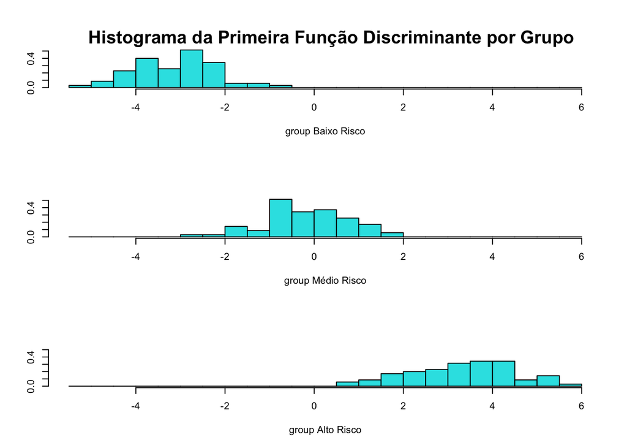

```r
# Plotar as funções discriminantes canônicas
lda_plot <- predict(modelo_lda, dados_treino)
ldahist(lda_plot$x[,1], g = dados_treino$grupo)
title("Histograma da Primeira Função Discriminante por Grupo")
```

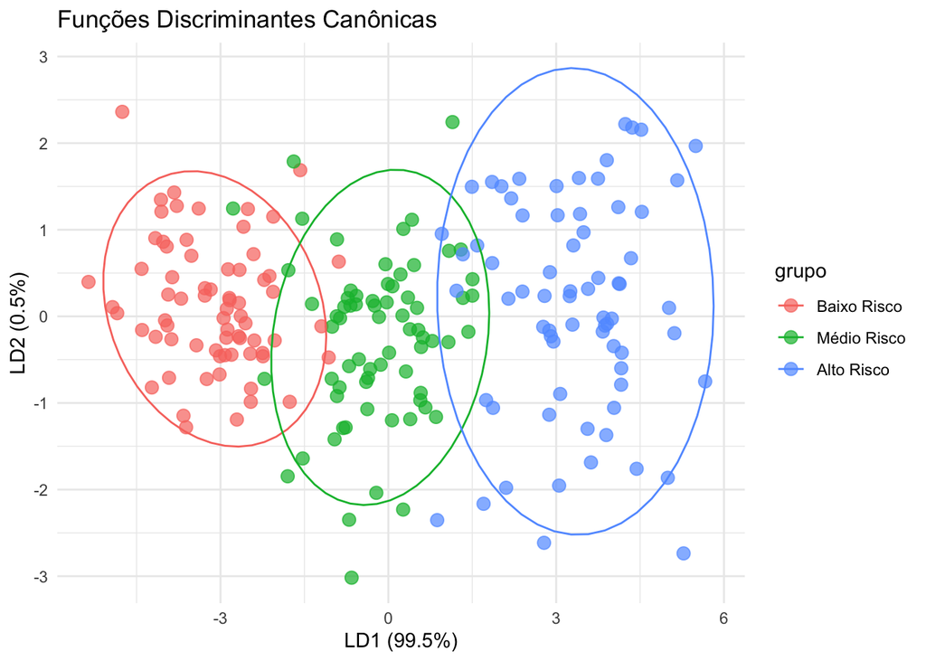

```r
# Gráfico de dispersão das duas primeiras funções discriminantes
plot_df <- data.frame(
  LD1 = lda_plot$x[,1],
  LD2 = lda_plot$x[,2],
  grupo = dados_treino$grupo
)

ggplot(plot_df, aes(x = LD1, y = LD2, color = grupo)) +
  geom_point(size = 3, alpha = 0.7) +
  stat_ellipse(level = 0.95) +
  labs(title = "Funções Discriminantes Canônicas",
       x = paste0("LD1 (", round(prop_var[1]*100, 1), "%)"),
       y = paste0("LD2 (", round(prop_var[2]*100, 1), "%)")) +
  theme_minimal()
```

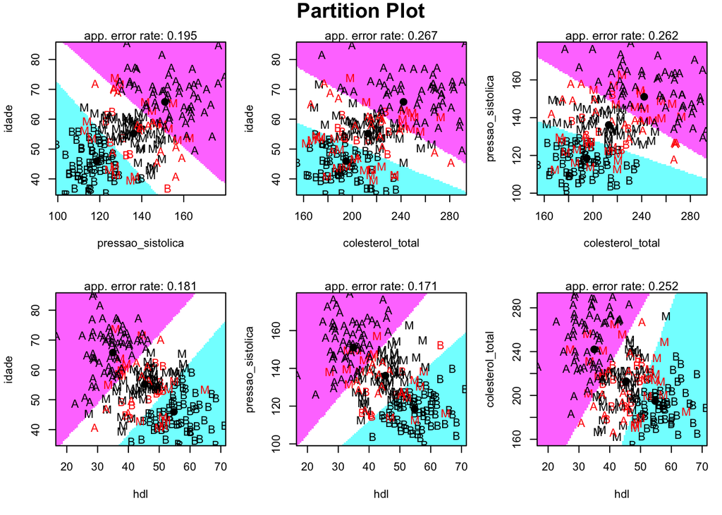

```r
# Visualizar a separação entre os grupos usando partimat
partimat(grupo ~ idade + pressao_sistolica + colesterol_total + hdl,
         data = dados_treino, method = "lda")
```

## 3.4 Avaliação do modelo no conjunto de teste

```r
# Fazer predições no conjunto de teste
predicoes <- predict(modelo_lda, dados_teste)
confusao <- table(Predito = predicoes$class, Real = dados_teste$grupo)
print(confusao)
```

```
##              Real
## Predito       Baixo Risco Médio Risco Alto Risco
##   Baixo Risco          28           2          0
##   Médio Risco           2          26          1
##   Alto Risco            0           2         29
```

```r
# Calcular a acurácia
acuracia <- sum(diag(confusao)) / sum(confusao)
cat("Acurácia do modelo: ", round(acuracia * 100, 2), "%\n")
```

```
## Acurácia do modelo:  92.22 %
```

```r
# Métricas de avaliação detalhadas
caret::confusionMatrix(predicoes$class, dados_teste$grupo)
```

```
## Confusion Matrix and Statistics
##
##              Reference
## Prediction    Baixo Risco Médio Risco Alto Risco
##   Baixo Risco          28           2          0
##   Médio Risco           2          26          1
##   Alto Risco            0           2         29
##
## Overall Statistics
##
##                Accuracy : 0.9222
##                  95% CI : (0.8463, 0.9682)
##     No Information Rate : 0.3333
##     P-Value [Acc > NIR] : < 2.2e-16
##
##                   Kappa : 0.8833
##
##  Mcnemar's Test P-Value : NA
##
## Statistics by Class:
##
##                      Class: Baixo Risco Class: Médio Risco Class: Alto Risco
## Sensitivity                      0.9333             0.8667            0.9667
## Specificity                      0.9667             0.9500            0.9667
## Pos Pred Value                   0.9333             0.8966            0.9355
## Neg Pred Value                   0.9667             0.9344            0.9831
## Prevalence                       0.3333             0.3333            0.3333
## Detection Rate                   0.3111             0.2889            0.3222
## Detection Prevalence             0.3333             0.3222            0.3444
## Balanced Accuracy                0.9500             0.9083            0.9667
```

```r
# Probabilidades posteriores para os primeiros casos
head(predicoes$posterior)
```

```
##    Baixo Risco  Médio Risco   Alto Risco
## 3    0.7051425 0.2948563122 1.178531e-06
## 6    0.9735277 0.0264722906 2.697277e-09
## 7    0.9420648 0.0579351525 1.532835e-08
## 9    0.9995404 0.0004595974 1.362528e-12
## 11   0.9970004 0.0029995779 5.702258e-11
## 18   0.9988423 0.0011577278 6.291188e-12
```

# 4. Interpretação dos Resultados

## 4.1 Análise das funções discriminantes

```r
# Examinar os coeficientes padronizados para entender a importância relativa de cada variável
coef_padronizados <- modelo_lda$scaling * apply(dados_treino[, 1:7], 2, sd)
coef_ordenados <- abs(coef_padronizados) %>%
  as.data.frame() %>%
  setNames(c("LD1", "LD2")) %>%
  arrange(desc(LD1))

print("Coeficientes padronizados (em ordem de importância para LD1):")
```

```
## [1] "Coeficientes padronizados (em ordem de importância para LD1):"
```

```r
print(coef_ordenados)
```

```
##                         LD1       LD2
## hdl               0.7487197 0.3050891
## pressao_sistolica 0.7209714 1.0756139
## idade             0.6700996 0.2499162
## imc               0.5681390 0.4273154
## glicemia          0.3633601 0.6787061
## colesterol_total  0.3386472 0.3859964
## triglicerideos    0.2883759 0.3596759
```

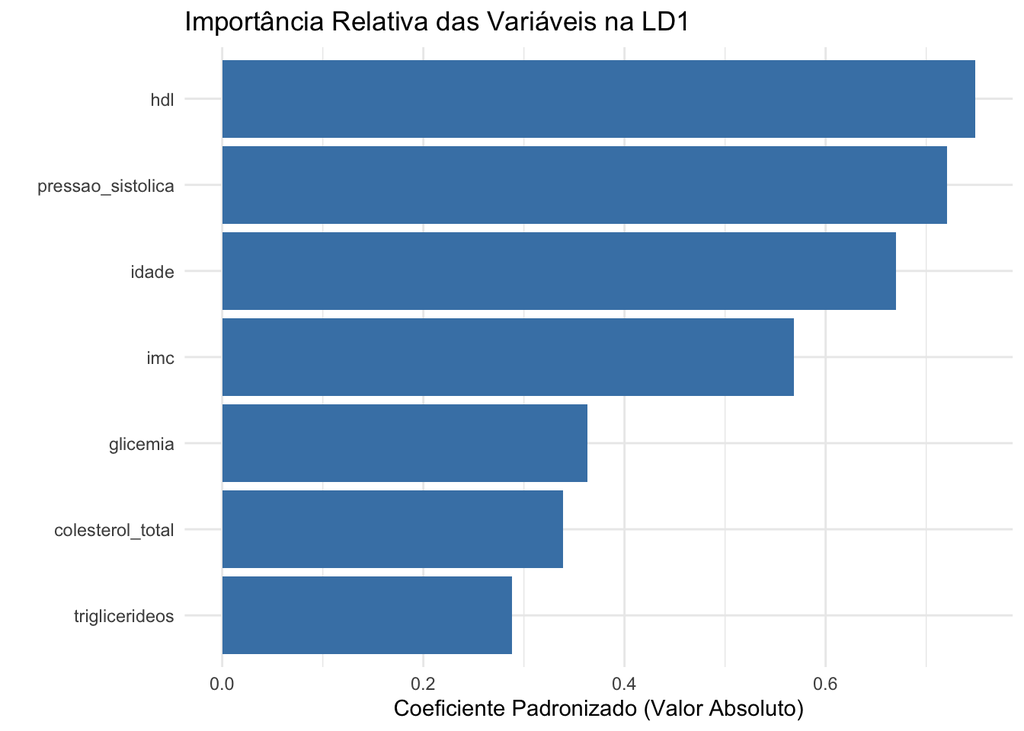

```r
# Visualizar a importância relativa das variáveis para a primeira função discriminante
variaveis <- rownames(coef_ordenados)
importancia_ld1 <- data.frame(
  variavel = variaveis,
  coeficiente = coef_ordenados$LD1
)

ggplot(importancia_ld1, aes(x = reorder(variavel, coeficiente), y = coeficiente)) +
  geom_bar(stat = "identity", fill = "steelblue") +
  coord_flip() +
  labs(title = "Importância Relativa das Variáveis na LD1",
       x = "", y = "Coeficiente Padronizado (Valor Absoluto)") +
  theme_minimal()
```

## 4.2 Mapa de classificação de novos pacientes

Vamos criar uma função para avaliar novos pacientes e classificá-los em grupos de risco.

```r
# Função para classificar novos pacientes
classificar_paciente <- function(idade, pressao_sistolica, colesterol_total,
                                hdl, triglicerideos, glicemia, imc) {

  # Criar dataframe com os dados do novo paciente
  novo_paciente <- data.frame(
    idade = idade,
    pressao_sistolica = pressao_sistolica,
    colesterol_total = colesterol_total,
    hdl = hdl,
    triglicerideos = triglicerideos,
    glicemia = glicemia,
    imc = imc
  )

  # Fazer predição usando o modelo LDA
  resultado <- predict(modelo_lda, novo_paciente)

  # Retornar o grupo predito e as probabilidades posteriores
  list(
    grupo_predito = as.character(resultado$class),
    probabilidades = resultado$posterior
  )
}

# Exemplo de uso da função com um novo paciente
novo_paciente <- classificar_paciente(
  idade = 58,
  pressao_sistolica = 142,
  colesterol_total = 230,
  hdl = 38,
  triglicerideos = 180,
  glicemia = 110,
  imc = 29.5
)

cat("Classificação do paciente: ", novo_paciente$grupo_predito, "\n")
```

```
## Classificação do paciente:  Alto Risco
```

```r
cat("Probabilidades por grupo:\n")
```

```
## Probabilidades por grupo:
```

```r
print(round(novo_paciente$probabilidades, 4))
```

```
##   Baixo Risco Médio Risco Alto Risco
## 1           0      0.4532     0.5468
```

# 5. Aplicação Prática e Tomada de Decisão

## 5.1 Protocolo de decisão baseado na Análise Discriminante

Com base nos resultados da Análise Discriminante, podemos criar um protocolo de decisão para orientar profissionais de saúde na avaliação de pacientes:

```r
# Definir limiares de decisão (exemplo)
limiar_confianca <- 0.8  # Probabilidade mínima para decisão automática

# Função de suporte à decisão
avaliar_risco_cardiovascular <- function(idade, pressao_sistolica, colesterol_total,
                                        hdl, triglicerideos, glicemia, imc) {

  # Classificar o paciente
  resultado <- classificar_paciente(idade, pressao_sistolica, colesterol_total,
                                   hdl, triglicerideos, glicemia, imc)

  # Probabilidade máxima
  prob_max <- max(resultado$probabilidades)
  grupo_max <- resultado$grupo_predito

  # Tomar decisão
  if (prob_max >= limiar_confianca) {
    decisao <- paste0("Classificar paciente como '", grupo_max,
                     "' com alta confiança (", round(prob_max*100, 1), "%).")
  } else {
    decisao <- paste0("Classificação incerta. Probabilidade do grupo mais provável ('",
                     grupo_max, "') é de apenas ", round(prob_max*100, 1),
                     "%. Considerar avaliação adicional.")
  }

  # Definir recomendações por grupo
  recomendacoes <- list(
    "Baixo Risco" = c(
      "Reavaliação em 12 meses",
      "Manter hábitos saudáveis",
      "Atividade física regular"
    ),
    "Médio Risco" = c(
      "Reavaliação em 6 meses",
      "Considerar ajustes na dieta",
      "Intensificar atividade física",
      "Monitorar pressão arterial e glicemia"
    ),
    "Alto Risco" = c(
      "Reavaliação em 3 meses",
      "Encaminhar para especialista",
      "Considerar terapia medicamentosa",
      "Monitoramento regular de pressão e perfil lipídico",
      "Plano de redução de peso se IMC elevado"
    )
  )

  # Retornar resultado estruturado
  list(
    classificacao = grupo_max,
    probabilidades = resultado$probabilidades,
    decisao = decisao,
    recomendacoes = recomendacoes[[grupo_max]]
  )
}

# Testar a função com três pacientes diferentes
pacientes_teste <- list(
  paciente1 = list(idade = 42, pressao_sistolica = 118, colesterol_total = 185,
                  hdl = 58, triglicerideos = 110, glicemia = 82, imc = 23.5),

  paciente2 = list(idade = 58, pressao_sistolica = 142, colesterol_total = 230,
                  hdl = 38, triglicerideos = 180, glicemia = 110, imc = 29.5),

  paciente3 = list(idade = 55, pressao_sistolica = 138, colesterol_total = 210,
                  hdl = 42, triglicerideos = 155, glicemia = 105, imc = 28.0)
)

# Avaliar cada paciente
for (i in 1:length(pacientes_teste)) {
  p <- pacientes_teste[[i]]
  nome_paciente <- names(pacientes_teste)[i]

  cat("\n\n===================================\n")
  cat("AVALIAÇÃO DO PACIENTE:", nome_paciente, "\n")
  cat("===================================\n")

  resultado <- avaliar_risco_cardiovascular(p$idade, p$pressao_sistolica, p$colesterol_total,
                                           p$hdl, p$triglicerideos, p$glicemia, p$imc)

  cat("Classificação: ", resultado$classificacao, "\n")
  cat("Probabilidades por grupo:\n")
  print(round(resultado$probabilidades, 4))
  cat("\nDecisão: ", resultado$decisao, "\n")
  cat("\nRecomendações:\n")
  for (rec in resultado$recomendacoes) {
    cat("- ", rec, "\n")
  }
}
```

```
##
##
## ===================================
## AVALIAÇÃO DO PACIENTE: paciente1
## ===================================
## Classificação:  Baixo Risco
## Probabilidades por grupo:
##   Baixo Risco Médio Risco Alto Risco
## 1      0.9984      0.0016          0
##
## Decisão:  Classificar paciente como 'Baixo Risco' com alta confiança (99.8%).
##
## Recomendações:
## -  Reavaliação em 12 meses
## -  Manter hábitos saudáveis
## -  Atividade física regular
##
##
## ===================================
## AVALIAÇÃO DO PACIENTE: paciente2
## ===================================
## Classificação:  Alto Risco
## Probabilidades por grupo:
##   Baixo Risco Médio Risco Alto Risco
## 1           0      0.4532     0.5468
##
## Decisão:  Classificação incerta. Probabilidade do grupo mais provável ('Alto Risco') é de apenas 54.7%. Considerar avaliação adicional.
##
## Recomendações:
## -  Reavaliação em 3 meses
## -  Encaminhar para especialista
## -  Considerar terapia medicamentosa
## -  Monitoramento regular de pressão e perfil lipídico
## -  Plano de redução de peso se IMC elevado
##
##
## ===================================
## AVALIAÇÃO DO PACIENTE: paciente3
## ===================================
## Classificação:  Médio Risco
## Probabilidades por grupo:
##   Baixo Risco Médio Risco Alto Risco
## 1      0.0026      0.9838     0.0136
##
## Decisão:  Classificar paciente como 'Médio Risco' com alta confiança (98.4%).
##
## Recomendações:
## -  Reavaliação em 6 meses
## -  Considerar ajustes na dieta
## -  Intensificar atividade física
## -  Monitorar pressão arterial e glicemia
```

# 6. Conclusões e Limitações da Técnica

## 6.1 Principais benefícios da Análise Discriminante no contexto médico

- Fornece uma estrutura objetiva para classificação de pacientes em grupos de risco
- Identifica quais fatores são mais importantes na discriminação entre grupos
- Permite calcular probabilidades de pertencimento a cada grupo
- Pode servir como base para protocolos de decisão clínica
- Facilita a comunicação de risco aos pacientes

## 6.2 Limitações a considerar

- Pressupõe normalidade multivariada dos dados e homogeneidade de variâncias-covariâncias
- Resultados podem ser sensíveis a outliers
- Necessita de amostras representativas para cada grupo
- Não lida bem com relações não-lineares entre variáveis
- Fronteiras de decisão são lineares, o que pode ser uma simplificação
- As probabilidades posteriores dependem das proporções dos grupos na amostra de treinamento

## 6.3 Possíveis extensões

- Análise Discriminante Quadrática (QDA) para relaxar a suposição de homogeneidade
- Regularização para lidar com multicolinearidade entre variáveis
- Validação cruzada para estimar melhor o erro de generalização
- Combinação com outras técnicas de classificação para decisões mais robustas

# 7. Referências Recomendadas